# Funciones de Estadística Básica

## Funciones Estadísticas en R

R es lenguaje bastante conocido por su buen manejo de análisis estadístico. En esta sesión revisaremos el uso de las funciones estadísticas más relevantes y que son usadas con mayor frecuencia.

Primero, una lista de comandos importantes de recordar:

```r
summary() # Resumen estadístico cuando son variables numéricas o integrales
mean() # El promedio de variables numéricas o integrales
min() # el mínimo de un conjunto de datos
max() # el máximo de un conjunto de datos
sd() # la desviación estándar de un conjunto de datos
var() # la variación muestral de un conjunto de datos
median() # la mediana de n conjunto de datos
table() # tabla de frecuencia
sum() #suma los puntajes
```

## Ejemplo- Cargando datos

Utilicemos la base de datos de la tabla de población INEI para poner estos comando en acción.

```r
# primero cargamos las librerías que utilizaremos
library(dplyr)
library(janitor)

#segundo cargamos los datos y limpiamos los nombres
inei <- read.csv("TB_POBLACION_INEI.csv") |>
  clean_names()
```

## Ejemplo - Usando las funciones

```r
# ahora probemos las funciones
summary(inei$cantidad)
```

```
##    Min. 1st Qu.  Median    Mean 3rd Qu.    Max.
##       0      23      59     263     161   61344
```

```r
mean(inei$cantidad)
```

```
## [1] 262.9773
```

```r
sum(inei$cantidad) # para saber el total de la población
```

```
## [1] 32526084
```

## Usando tablas de resumen

Digamos que ahora quiero saber la cantidad de pobladores según departamento o edad, quiero armar una tabla de la misma. Para eso existe la posibilidad de crear tablas resumen.

Debido a que la base de datos de INEI es una base resumen en sí, la mejor opción es usar las funciones de dplyr.

```r
# probemos con departamento

tabla_1 <- inei |>
  group_by(departamento) |>
  summarise(cantidad = sum(cantidad)) |>
  arrange(-cantidad) # para ordenar lo datos

tabla_1
```

```
## # A tibble: 25 × 2
##    departamento cantidad
##    <chr>           <int>
##  1 LIMA         10458367
##  2 LA LIBERTAD   1956389
##  3 PIURA         1901896
##  4 CAJAMARCA     1543104
##  5 PUNO          1471405
##  6 JUNIN         1389850
##  7 AREQUIPA      1350676
##  8 CUSCO         1346373
##  9 LAMBAYEQUE    1300720
## 10 ANCASH        1171756
## # … with 15 more rows
## # ℹ Use `print(n = ...)` to see more rows
```

## Graficando nuestros resultados

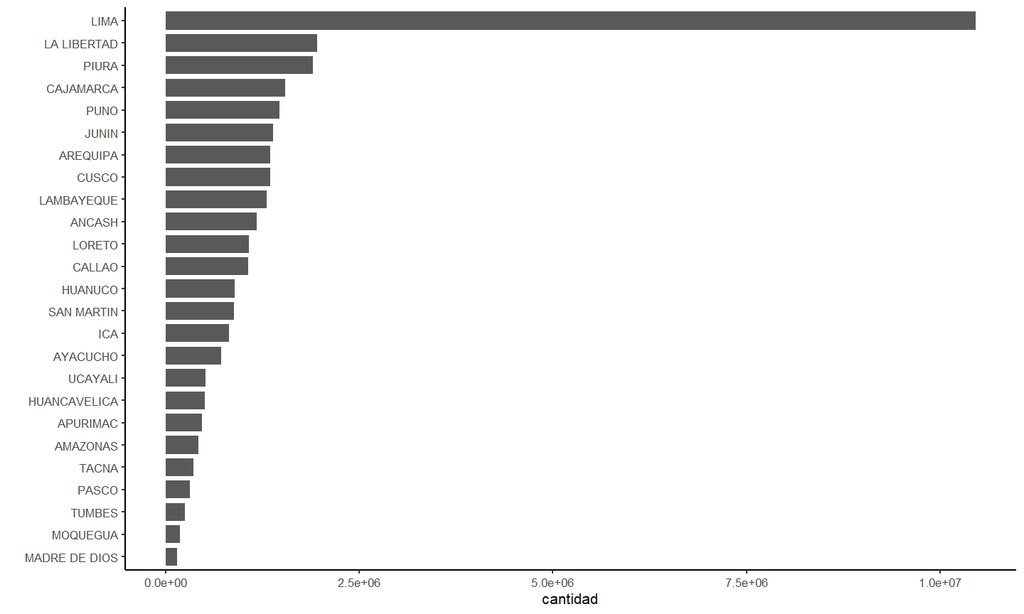

```r
library(ggplot2)

tabla_1 |> ggplot(aes(x = reorder(departamento, cantidad), y = cantidad)) +
  geom_bar(stat = "identity", width = 0.8) + # con width reduzco el ancho de barras
  theme_classic(base_size = 8) + # uso una plantilla y con base_size reduzco la letra
  xlab("") + #retiro el título del eje inferior
  coord_flip()
```

## Resumen datos por edad

```r
# probemos con departamento

tabla_2 <- inei |>
  group_by(edad_anio) |>
  summarise(cantidad = sum(cantidad)) |>
  arrange(-cantidad) # para ordenar lo datos

tabla_2
```

```
## # A tibble: 33 × 2
##    edad_anio cantidad
##    <chr>        <int>
##  1 20-24      2841328
##  2 25-29      2765677
##  3 30-34      2574016
##  4 35-39      2333212
##  5 40-44      2174557
##  6 45-49      1885171
##  7 50-54      1637067
##  8 55-59      1389893
##  9 60-64      1103347
## 10 65-69       860988
## # … with 23 more rows
## # ℹ Use `print(n = ...)` to see more rows
```

## Gráfico de barras para la cantidad de pobladores por edad

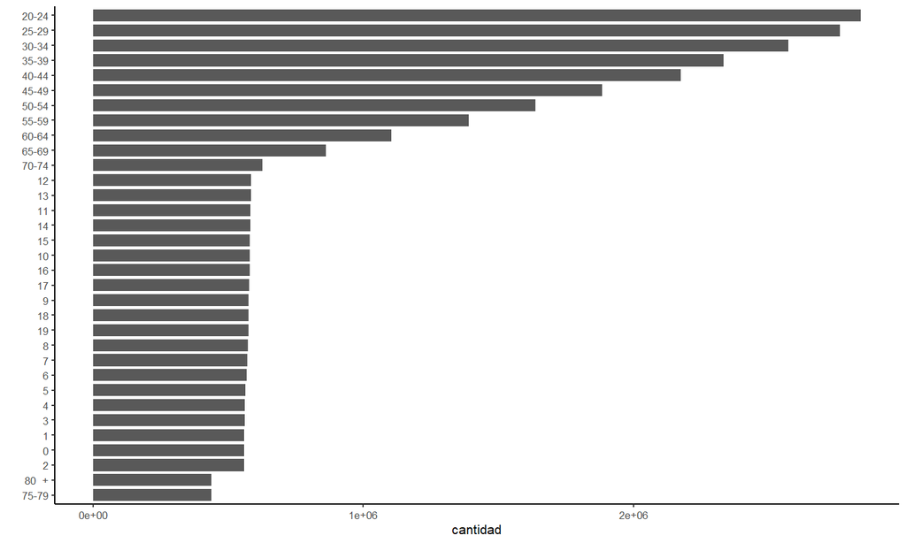

```r
library(ggplot2)

tabla_2 |> ggplot(aes(x = reorder(edad_anio, cantidad), y = cantidad)) +
  geom_bar(stat = "identity", width = 0.8) +
  theme_classic(base_size = 8) +
  xlab("") +
  coord_flip()
```

## Base de Datos Ordenada

Una base de datos ordenada o “tidy” es una base donde cada data nuevo se registra en una fila. En el caso de INEI por ejemplo en vez de tener 123 mil registros debería de haber un más de 32 millones de filas, lo que representaría a cada ciudadno del Perú.

Un buen ejemplo de bases ordenadas son las bases provenientes de encuestas. Al tener este tipo de base se nos permitirá realizar un mejor uso de las funciones estadísticas.

Para este caso crearemos nuestra propia base.

```r
id <- seq(1:200)
edad <- sample(c("0-15", "16-29", "30-44", "45-64"), 200, replace = TRUE)
sexo <- sample(c("Hombre", "Mujer"), 200, replace = TRUE)
departamento <- sample(c("Lima", "Arequipa", "Cusco", "Piura", "Trujillo"),
                    200, replace = TRUE)
peso <- sample(c("Debajo", "Regular", "Sobrepeso"), 200, replace = TRUE)
salud <- sample(c("Mala", "Promedio", "Buena"), 200, replace = TRUE)
encuesta <- data.frame(edad, sexo, departamento, peso, salud)
```

## Tabla Cruzada

Haremos una tabla cruzada de frecuencias entre edad y sexo. Para ello utilizaremos el comando table. Luego usaremos la función prop.table para extraer los porcentajes y con ayuda del paquete xtable imprimiremos la tabla.

```r
library(xtable)

tabla_2 <- table(encuesta$edad, encuesta$sexo)
print(xtable(tabla_2), type = "html")
```

|  | Hombre | Mujer |
| --- | --- | --- |
| 0-15 | 22 | 26 |
| 16-29 | 30 | 20 |
| 30-44 | 18 | 27 |
| 45-64 | 25 | 32 |

```r
tabla_3 <- prop.table(tabla_2)
print(xtable(tabla_3), type = "html")
```

|  | Hombre | Mujer |
| --- | --- | --- |
| 0-15 | 0.11 | 0.13 |
| 16-29 | 0.15 | 0.10 |
| 30-44 | 0.09 | 0.14 |
| 45-64 | 0.12 | 0.16 |

## Hagamos una regresión-Parte 1

Para realizar las correlaciones o regresiones es recomendable transformar las variables de interés en variables numéricas. Nuestras variables de interés son peso y salud y por ello, en primer lugar transformaremos dichas variables categóricas.

```r
encuesta_transf <- encuesta |>
  mutate(peso = if_else(peso == "Debajo", 1,
                        if_else(peso == "Regular", 2, 3)),
         salud = if_else(salud == "Mala", 1,
                         if_else(salud == "Promedio", 2, 3)))

encuesta_transf
```

```
##      edad   sexo departamento peso salud
## 1   30-44  Mujer        Piura    1     3
## 2   45-64 Hombre     Trujillo    3     3
## 3   30-44 Hombre     Trujillo    3     2
## 4   45-64  Mujer        Cusco    1     1
## 5    0-15  Mujer        Cusco    3     3
## 6    0-15 Hombre        Cusco    3     3
## 7    0-15 Hombre        Piura    2     1
## 8    0-15  Mujer     Trujillo    3     2
## 9   30-44 Hombre     Arequipa    2     1
## 10  30-44  Mujer        Cusco    1     3
## 11  45-64 Hombre        Piura    2     2
## 12  30-44 Hombre     Trujillo    1     3
## 13  16-29 Hombre        Cusco    1     1
## 14  16-29 Hombre     Arequipa    3     2
```

[output cut: 186 more lines]

## Hagamos una regresión-Parte 2

Ahora podremos trabajar las regresiones, pero primero hagamos una correlación.

Los coeficientes de correlación van desde -1 hasta 1.

Cómo se darán cuenta nos salió un coeficiente bajo.

```r
cor(encuesta_transf$peso, encuesta_transf$salud)
```

```
## [1] -0.07365493
```

## Hagamos una regresión-Parte 3

Ahora para realizar una regresión, se debe de usar la siguiente fórmula, a la izquierda la variable dependiente y a la derecha la variable independiente. Con la función summary veremos los resultados.

```r
modelo_1 <- lm(salud~peso, encuesta_transf)
summary(modelo_1)
```

```
##
## Call:
## lm(formula = salud ~ peso, data = encuesta_transf)
##
## Residuals:
##     Min      1Q  Median      3Q     Max
## -1.0248 -0.9488  0.0512  0.9752  1.1272
##
## Coefficients:
##             Estimate Std. Error t value Pr(>|t|)
## (Intercept)  2.10080    0.16172  12.991   <2e-16 ***
## peso        -0.07600    0.07313  -1.039      0.3
## ---
## Signif. codes:  0 '***' 0.001 '**' 0.01 '*' 0.05 '.' 0.1 ' ' 1
##
## Residual standard error: 0.8575 on 198 degrees of freedom
## Multiple R-squared:  0.005425,   Adjusted R-squared:  0.0004019
## F-statistic:  1.08 on 1 and 198 DF,  p-value: 0.3
```